# Activity 9.2

Author

Devakinandan Palla

Our dataset consists of clinical data from patients who entered the hospital complaining of chest pain (“angina”) during exercise. The information collected includes:

- `age` : Age of the patient
- `sex` : Sex of the patient
- `cp` : Chest Pain type
  - Value 0: asymptomatic
  - Value 1: typical angina
  - Value 2: atypical angina
  - Value 3: non-anginal pain
- `trtbps` : resting blood pressure (in mm Hg)
- `chol` : cholesterol in mg/dl fetched via BMI sensor
- `restecg` : resting electrocardiographic results
  - Value 0: normal
  - Value 1: having ST-T wave abnormality (T wave inversions and/or ST elevation or depression of > 0.05 mV)
  - Value 2: showing probable or definite left ventricular hypertrophy by Estes’ criteria
- `thalach` : maximum heart rate achieved during exercise
- `output` : the doctor’s diagnosis of whether the patient is at risk for a heart attack
  - 0 = not at risk of heart attack
  - 1 = at risk of heart attack

```python
import pandas as pd
from sklearn.model_selection import train_test_split
from sklearn.neighbors import KNeighborsClassifier
from sklearn.tree import DecisionTreeClassifier, plot_tree
from sklearn.discriminant_analysis import LinearDiscriminantAnalysis as LDA
from sklearn.metrics import classification_report
import matplotlib.pyplot as plt
```

```python
heart_data = pd.read_csv("/content/heart_attack.csv")
heart_data
```

|  | age | sex | cp | trtbps | chol | restecg | thalach | output |
| --- | --- | --- | --- | --- | --- | --- | --- | --- |
| 0 | 63 | 1 | 3 | 145 | 233 | 0 | 150 | 1 |
| 1 | 37 | 1 | 2 | 130 | 250 | 1 | 187 | 1 |
| 2 | 56 | 1 | 1 | 120 | 236 | 1 | 178 | 1 |
| 3 | 57 | 0 | 0 | 120 | 354 | 1 | 163 | 1 |
| 4 | 57 | 1 | 0 | 140 | 192 | 1 | 148 | 1 |
| ... | ... | ... | ... | ... | ... | ... | ... | ... |
| 268 | 59 | 1 | 0 | 164 | 176 | 0 | 90 | 0 |
| 269 | 57 | 0 | 0 | 140 | 241 | 1 | 123 | 0 |
| 270 | 45 | 1 | 3 | 110 | 264 | 1 | 132 | 0 |
| 271 | 68 | 1 | 0 | 144 | 193 | 1 | 141 | 0 |
| 272 | 57 | 0 | 1 | 130 | 236 | 0 | 174 | 0 |

273 rows × 8 columns

## Q1: Natural Multiclass Models

Fit a multiclass KNN, Decision Tree, and LDA for the heart disease data; this time predicting the type of chest pain (categories 0 - 3) that a patient experiences. For the decision tree, plot the fitted tree, and interpret the first couple splits.

```python
X = heart_data.drop(columns=["cp"])
y = heart_data["cp"]

X_train, X_test, y_train, y_test = train_test_split(X, y, test_size=0.3, random_state=42, stratify=y)

X_train.shape, X_test.shape, y_train.shape, y_test.shape
```

```
((191, 7), (82, 7), (191,), (82,))
```

```python
knn = KNeighborsClassifier(n_neighbors=5)
knn.fit(X_train, y_train)

knn_predictions = knn.predict(X_test)

knn_report = classification_report(y_test, knn_predictions, output_dict=False)
print(knn_report)
```

```
              precision    recall  f1-score   support

           0       0.54      0.74      0.62        39
           1       0.33      0.23      0.27        13
           2       0.39      0.29      0.33        24
           3       0.00      0.00      0.00         6

    accuracy                           0.48        82
   macro avg       0.31      0.32      0.31        82
weighted avg       0.42      0.48      0.44        82
```

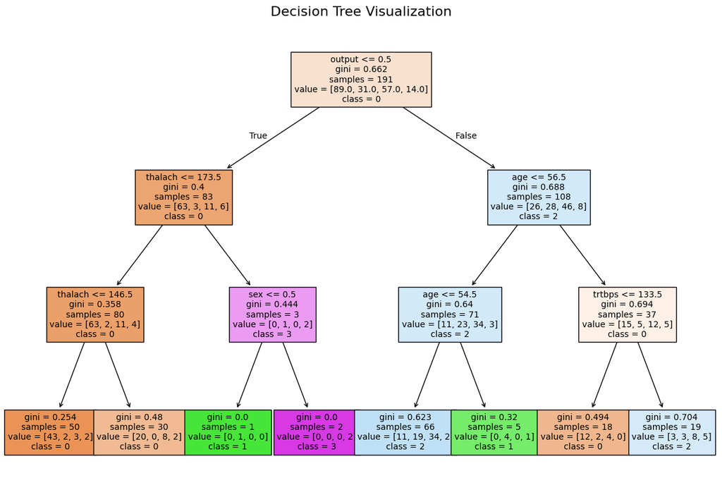

```
'              precision    recall  f1-score   support\n\n           0       0.67      0.77      0.71        39\n           1       1.00      0.15      0.27        13\n           2       0.47      0.62      0.54        24\n           3       0.00      0.00      0.00         6\n\n    accuracy        …
```

```python
# Fitting a Decision Tree classifier
decision_tree = DecisionTreeClassifier(random_state=42, max_depth=3)
decision_tree.fit(X_train, y_train)

dt_predictions = decision_tree.predict(X_test)
dt_report = classification_report(y_test, dt_predictions, output_dict=False)
plt.figure(figsize=(15, 10))
plot_tree(decision_tree, feature_names=X.columns, class_names=['0', '1', '2', '3'], filled=True, fontsize=10)
plt.title("Decision Tree Visualization", fontsize=16)
plt.show()

dt_report
```

```python
# Fitting an LDA model
lda = LDA()
lda.fit(X_train, y_train)

# Predictions using the LDA model
lda_predictions = lda.predict(X_test)

# Evaluating the LDA model
lda_report = classification_report(y_test, lda_predictions, output_dict=False)
print(lda_report)
```

```
              precision    recall  f1-score   support

           0       0.70      0.79      0.75        39
           1       0.19      0.23      0.21        13
           2       0.48      0.42      0.44        24
           3       0.00      0.00      0.00         6

    accuracy                           0.54        82
   macro avg       0.34      0.36      0.35        82
weighted avg       0.50      0.54      0.52        82
```

First split: Based on output (heart attack risk):

output ≤ 0.5: Further split by thalach (max heart rate).

output > 0.5: Further split by age.

Second split:

For output ≤ 0.5: thalach ≤ 173.5 separates classes.

For output > 0.5: age ≤ 56.5 separates classes.

## Q2: OvR

Create a new column in the `ha` dataset called `cp_is_3`, which is equal to `1` if the `cp` variable is equal to `3` and `0` otherwise.

Then, fit a Logistic Regression to predict this new target, and report the **F1 Score**.

Repeat for the other three `cp` categories. Which category was the OvR approach best at distinguishing?

```python
from sklearn.linear_model import LogisticRegression
from sklearn.metrics import f1_score
f1_scores = {}

for category in range(4):
    heart_data[f"cp_is_{category}"] = (heart_data["cp"] == category).astype(int)

    X = heart_data.drop(columns=["cp", f"cp_is_{category}"])
    y = heart_data[f"cp_is_{category}"]
    X_train, X_test, y_train, y_test = train_test_split(X, y, test_size=0.3, random_state=42, stratify=y)

    logistic_model = LogisticRegression(max_iter=1000, random_state=42)
    logistic_model.fit(X_train, y_train)

    predictions = logistic_model.predict(X_test)
    f1 = f1_score(y_test, predictions)
    f1_scores[f"cp_is_{category}"] = f1
sorted_f1_scores = {k: v for k, v in sorted(f1_scores.items(), key=lambda item: item[1], reverse=True)}
sorted_f1_scores
```

```
{'cp_is_2': 0.8727272727272727,
 'cp_is_0': 0.75,
 'cp_is_3': 0.2857142857142857,
 'cp_is_1': 0.125}
```

The OvR approach performed best at distinguishing Category 2 (atypical angina)

## Q3: OvO

Reduce your dataset to only the `0` and `1` types of chest pain.

Then, fit a Logistic Regression to predict between the two groups, and report the **ROC-AUC**.

Repeat comparing category `0` to `2` and `3`. Which pair was the OvO approach best at distinguishing?

```python
from sklearn.pipeline import Pipeline
from sklearn.preprocessing import StandardScaler
from sklearn.linear_model import LogisticRegression
from sklearn.model_selection import cross_val_score
```

```python
# Function to calculate ROC-AUC for cp=0 vs another category
def calculate_roc_auc(data, category_to_compare):
    """
    Filters the dataset to include only cp=0 and the specified comparison category,
    trains a Logistic Regression model, and calculates the mean ROC-AUC using cross-validation.

    Parameters:
    - data: DataFrame containing the dataset.
    - category_to_compare: Chest pain category to compare with cp=0.

    Returns:
    - Mean ROC-AUC score for the comparison.
    """
    filtered_data = data[data["cp"].isin([0, category_to_compare])]

    X = filtered_data[["age", "chol"]]
    y = filtered_data["cp"]

    logistic_pipeline = Pipeline([
        ("scaler", StandardScaler()),
        ("logistic_model", LogisticRegression(max_iter=200, random_state=42, class_weight="balanced", C=0.1))
    ])

    roc_auc_scores = cross_val_score(logistic_pipeline, X, y, cv=5, scoring="roc_auc")
    return roc_auc_scores.mean()
```

```python
roc_auc_0_vs_1 = calculate_roc_auc(heart_data, 1)
roc_auc_0_vs_2 = calculate_roc_auc(heart_data, 2)
roc_auc_0_vs_3 = calculate_roc_auc(heart_data, 3)

print(f"ROC-AUC for cp=0 vs cp=1: {roc_auc_0_vs_1:.4f}")
print(f"ROC-AUC for cp=0 vs cp=2: {roc_auc_0_vs_2:.4f}")
print(f"ROC-AUC for cp=0 vs cp=3: {roc_auc_0_vs_3:.4f}")

roc_auc_results = {"0_vs_1": roc_auc_0_vs_1, "0_vs_2": roc_auc_0_vs_2, "0_vs_3": roc_auc_0_vs_3}
best_comparison = max(roc_auc_results, key=roc_auc_results.get)
print(f"\nThe OvO approach performed best for: {best_comparison} with ROC-AUC = {roc_auc_results[best_comparison]:.4f}")
```

```
ROC-AUC for cp=0 vs cp=1: 0.6029
ROC-AUC for cp=0 vs cp=2: 0.5827
ROC-AUC for cp=0 vs cp=3: 0.3868

The OvO approach performed best for: 0_vs_1 with ROC-AUC = 0.6029
```